# Ovarian_dataset_survival_analysis

3/9/2021

Today we will analize Ovarian dataset with treatment of patients with advanced ovarian carcinoma (stages IIIB and IV) using either cyclophosphamide alone (1 g/m2) or cyclophosphamide (500 mg/m2) plus adriamycin (40 mg/m2) by iv injection every 3 weeks each produced partial regression in approximately one third of the patients.

First, let’s look at our data.

##EDA analysis

Importing dataset and seeng the structure:

```r
data("ovarian")
ovarian <- data.frame(ovarian)
str(ovarian)
```

```
## 'data.frame':    26 obs. of  6 variables:
##  $ futime  : num  59 115 156 421 431 448 464 475 477 563 ...
##  $ fustat  : num  1 1 1 0 1 0 1 1 0 1 ...
##  $ age     : num  72.3 74.5 66.5 53.4 50.3 ...
##  $ resid.ds: num  2 2 2 2 2 1 2 2 2 1 ...
##  $ rx      : num  1 1 1 2 1 1 2 2 1 2 ...
##  $ ecog.ps : num  1 1 2 1 1 2 2 2 1 2 ...
```

```r
help(ovarian)
```

futime: survival or censoring time fustat: censoring status age: in years resid.ds: residual disease present (1=no,2=yes) rx: treatment group ecog.ps: ECOG performance status (1 is better, see reference)

We can see some factor variables, so we can change the data type for them:

```r
ovarian$rx <- factor(ovarian$rx)

ovarian$resid.ds <- factor(ovarian$resid.ds)

ovarian$ecog.ps <- factor(ovarian$ecog.ps)
```

And let’s evaluate the distribution of our numeric variables:

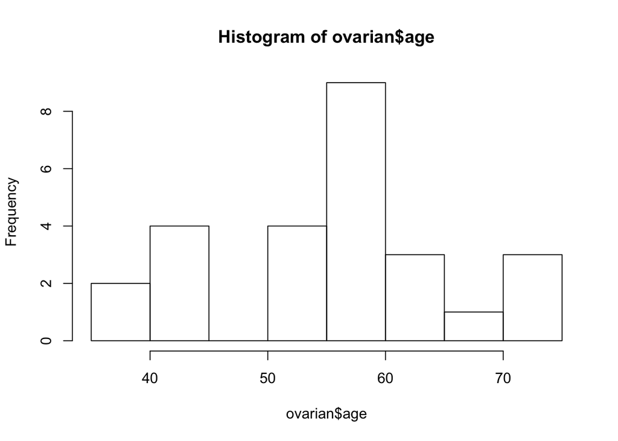

```r
hist(ovarian$age)
```

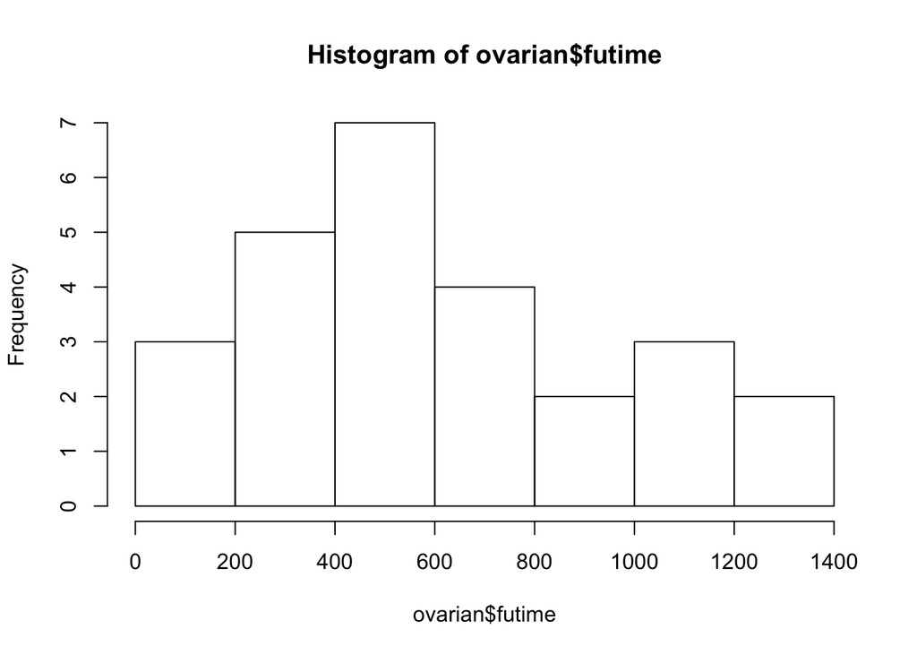

```r
hist(ovarian$futime)
```

```r
ovarian <- ovarian %>% mutate(age_group = ifelse(age >=50, "old", "young"))

ovarian$age_group <- factor(ovarian$age_group)
```

Check our data for NA:

```r
number_NA <- sum(is.na(ovarian))
number_NA
```

```
## [1] 0
```

We don’t have any problems with our data^ so we can start the survival analysis

## Kaplan-Meier curves

It helps to estimate the probability of death of a particular individual depending on the time. First, we need to get the survival timeline (the time interval within which we will assess the survival rate).

```r
km <- with(ovarian, Surv(futime, fustat))
head(km, 26)
```

```
##  [1]   59   115   156   421+  431   448+  464   475   477+  563   638   744+
## [13]  769+  770+  803+  855+ 1040+ 1106+ 1129+ 1206+ 1227+  268   329   353
## [25]  365   377+
```

Next, we build a linear model that accounts for the factor-based change in survival over time.

```r
km_fit <- survfit(Surv(futime, fustat) ~ 1, data=ovarian)
summary(km_fit, times = c(1,30,60,90*(1:10)))
```

```
## Call: survfit(formula = Surv(futime, fustat) ~ 1, data = ovarian)
##
##  time n.risk n.event survival std.err lower 95% CI upper 95% CI
##     1     26       0    1.000  0.0000        1.000        1.000
##    30     26       0    1.000  0.0000        1.000        1.000
##    60     25       1    0.962  0.0377        0.890        1.000
##    90     25       0    0.962  0.0377        0.890        1.000
##   180     23       2    0.885  0.0627        0.770        1.000
##   270     22       1    0.846  0.0708        0.718        0.997
##   360     20       2    0.769  0.0826        0.623        0.949
##   450     15       2    0.688  0.0919        0.529        0.894
##   540     12       2    0.596  0.0999        0.429        0.828
##   630     11       1    0.546  0.1032        0.377        0.791
##   720     10       1    0.497  0.1051        0.328        0.752
##   810      6       0    0.497  0.1051        0.328        0.752
##   900      5       0    0.497  0.1051        0.328        0.752
```

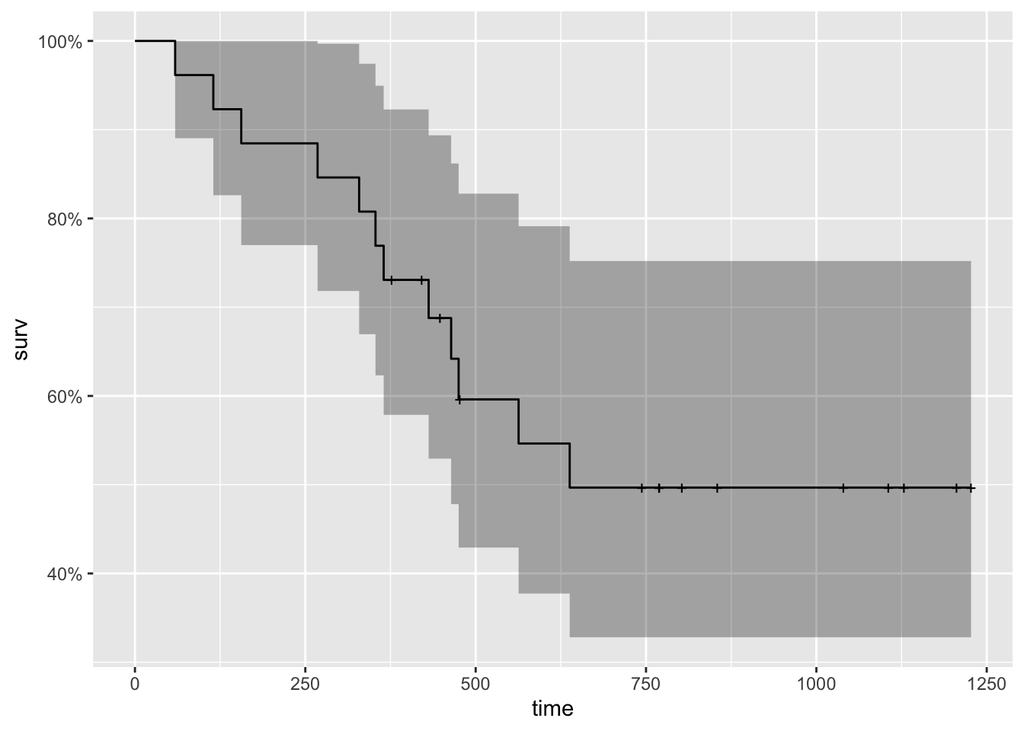

```r
autoplot(km_fit)
```

Let’s take a look at how the type of treatment affects survival.

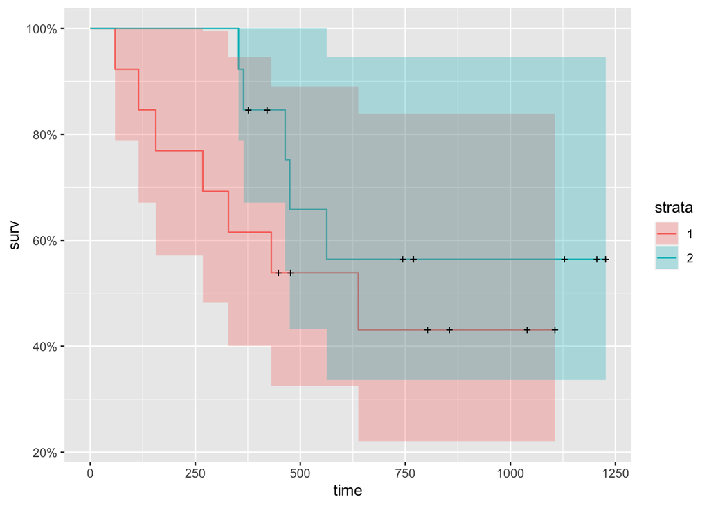

```r
km_trt_fit <- survfit(Surv(futime, fustat) ~ rx, data=ovarian)
autoplot(km_trt_fit)
```

We see that treatment A(1) has less effect than treatment B(2).

We divide patients by age, into those who are under 50 and over 50. It can be seen that the probability of living more than a year in patients under 50 years of age is much higher (over 80%) than in older patients.

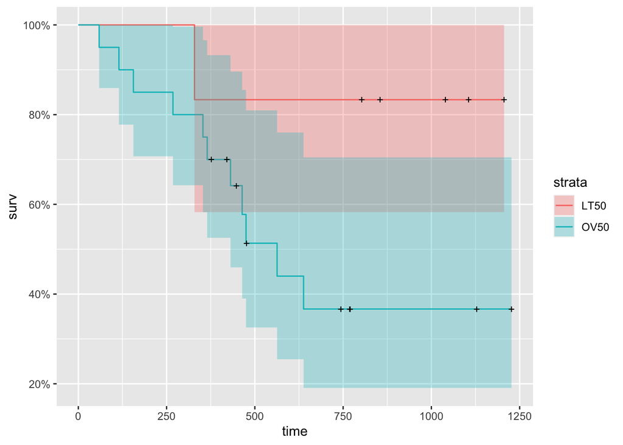

```r
vet <- mutate(ovarian, age_group = ifelse((age < 50), "LT50", "OV50"),
              AG = factor(age_group),
              trt = factor(rx,labels=c("A","B")))


km_AG_fit <- survfit(Surv(futime, fustat) ~ age_group, data=vet)
autoplot(km_AG_fit)
```

Next, we evaluated how the incidence rate of people who remained ill and who were completely cured was changing. It is logical that we see that in people who no longer have the disease, the survival graph looks better.

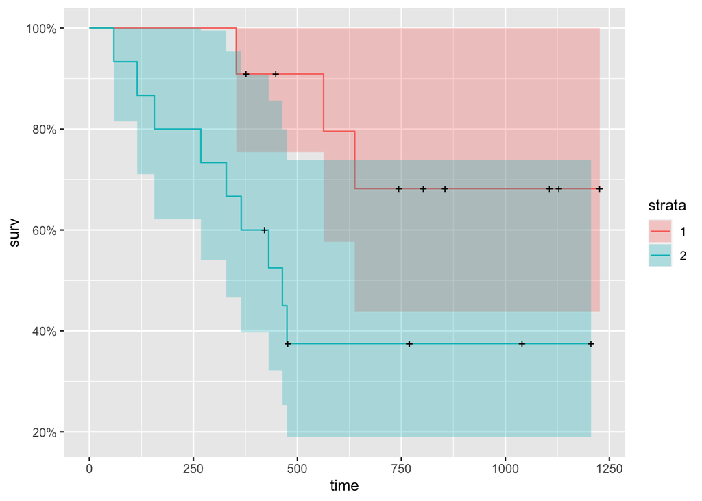

```r
km_resid_fit <- survfit(Surv(futime, fustat) ~ resid.ds, data=ovarian)
autoplot(km_resid_fit)
```

When comparing the two treatment options, we see that the second treatment (cyclophosphamide (500 mg/m2) plus adriamycin (40 mg/m2)) option was more effective than the first (cyclophosphamide alone (1 g/m2).

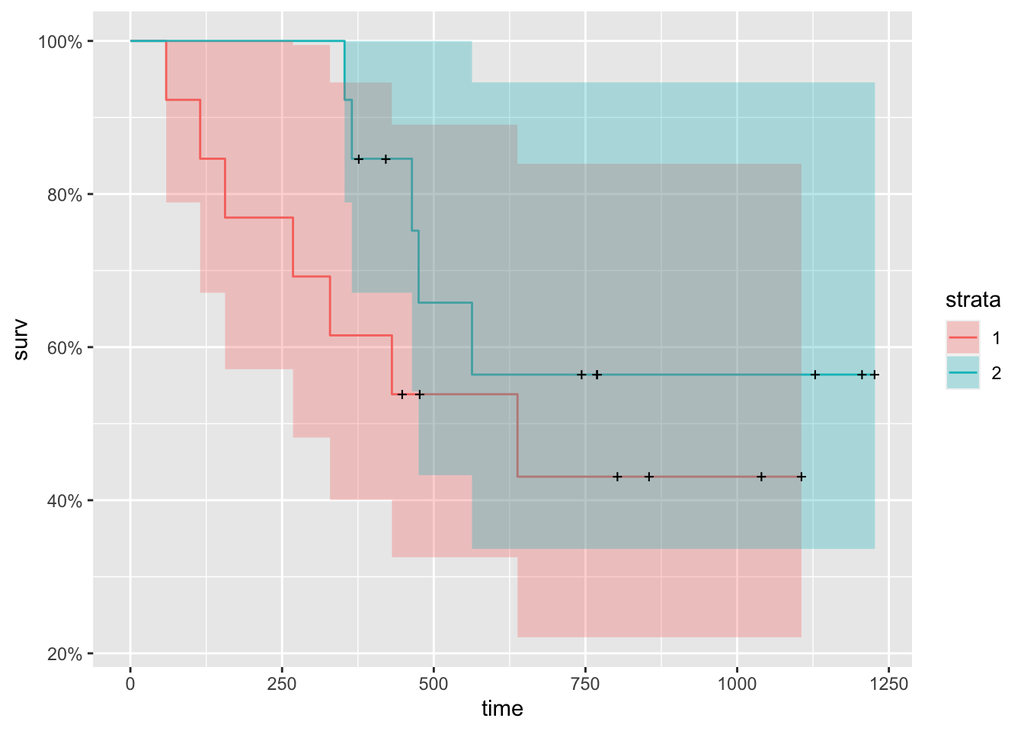

```r
km_rx_fit <- survfit(Surv(futime, fustat) ~ rx, data=ovarian)
autoplot(km_rx_fit)
```

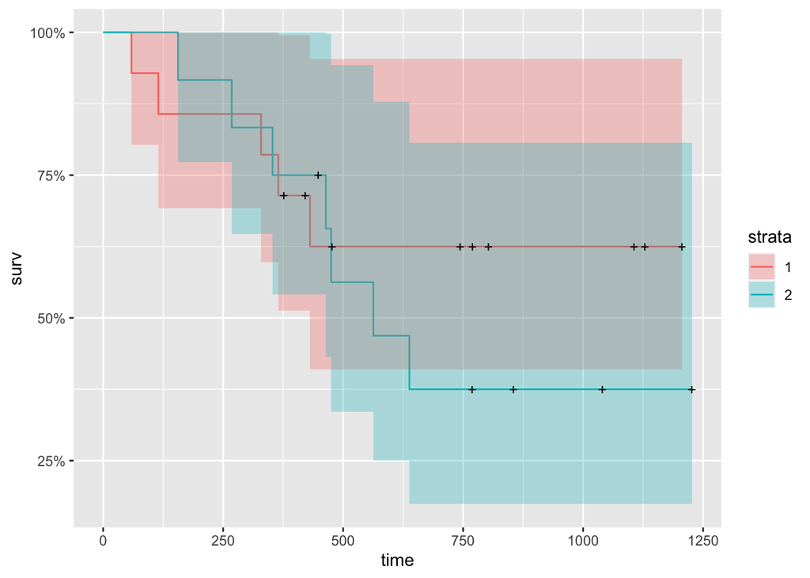

```r
km_ecog_fit <- survfit(Surv(futime, fustat) ~ ecog.ps, data=ovarian)
autoplot(km_ecog_fit)
```

## Assess the factors that influence the risk and assess the risk ratio

```r
cox <- coxph(Surv(futime, fustat) ~ age + resid.ds + rx + ecog.ps , data = ovarian)
summary(cox)
```

```
## Call:
## coxph(formula = Surv(futime, fustat) ~ age + resid.ds + rx +
##     ecog.ps, data = ovarian)
##
##   n= 26, number of events= 12
##
##               coef exp(coef) se(coef)      z Pr(>|z|)
## age        0.12481   1.13294  0.04689  2.662  0.00777 **
## resid.ds2  0.82619   2.28459  0.78961  1.046  0.29541
## rx2       -0.91450   0.40072  0.65332 -1.400  0.16158
## ecog.ps2   0.33621   1.39964  0.64392  0.522  0.60158
## ---
## Signif. codes:  0 '***' 0.001 '**' 0.01 '*' 0.05 '.' 0.1 ' ' 1
##
##           exp(coef) exp(-coef) lower .95 upper .95
## age          1.1329     0.8827    1.0335     1.242
## resid.ds2    2.2846     0.4377    0.4861    10.738
## rx2          0.4007     2.4955    0.1114     1.442
## ecog.ps2     1.3996     0.7145    0.3962     4.945
##
## Concordance= 0.807  (se = 0.068 )
## Likelihood ratio test= 17.04  on 4 df,   p=0.002
## Wald test            = 14.25  on 4 df,   p=0.007
## Score (logrank) test = 20.81  on 4 df,   p=3e-04
```

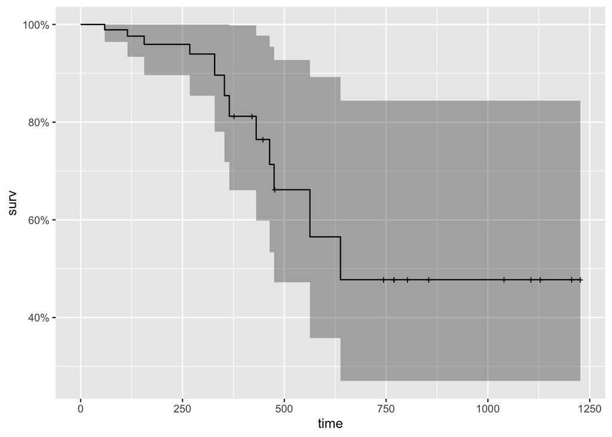

```r
cox_fit <- survfit(cox)
autoplot(cox_fit)
```

We see that this survival model is significantly influenced only by the patient’s age.

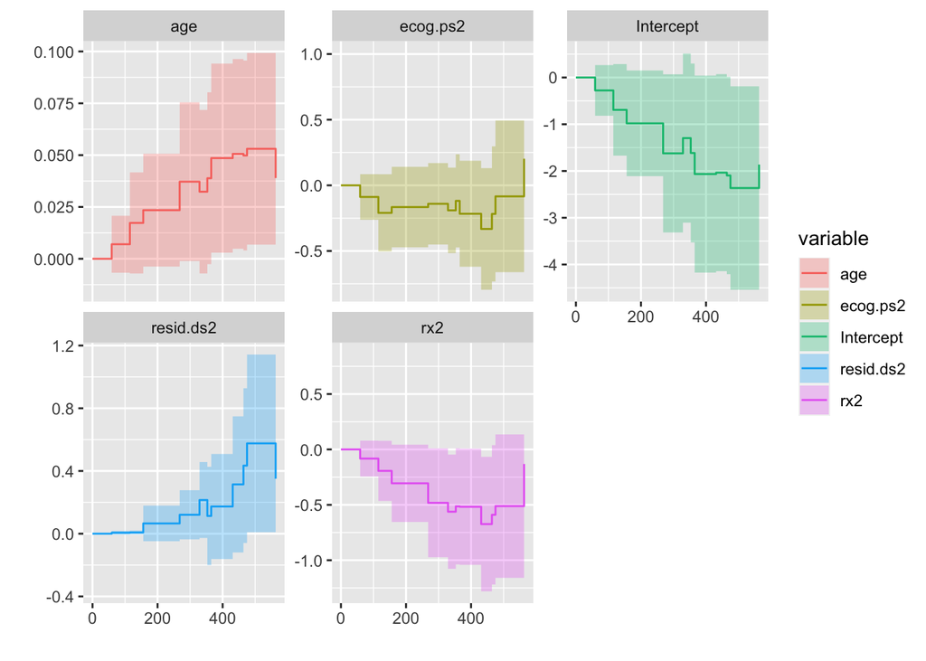

```r
aa_fit <- aareg(Surv(futime, fustat) ~ age + resid.ds + rx + ecog.ps, data = ovarian)
autoplot(aa_fit)
```

## Hazard Ratio

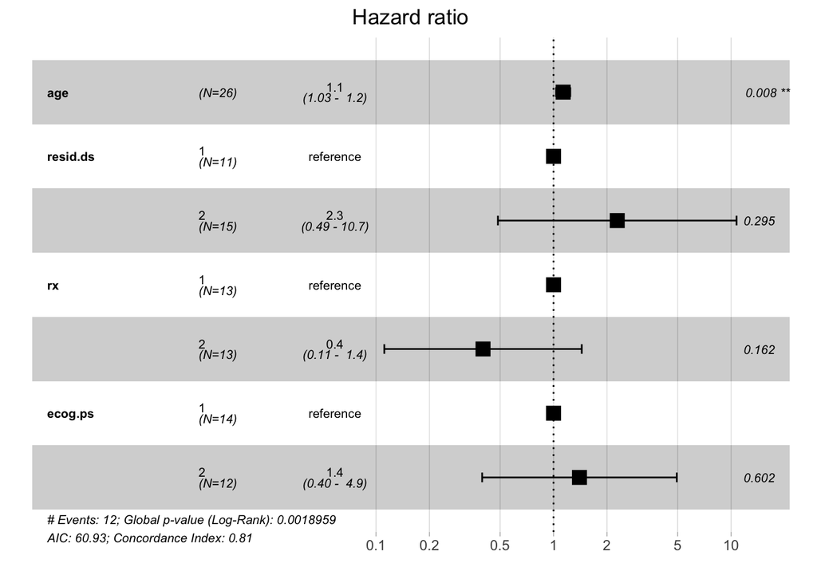

```r
fit.coxph <- coxph(Surv(futime, fustat) ~ age + resid.ds + rx + ecog.ps, data = ovarian)
ggforest(fit.coxph, data = ovarian)
```

On this Hazard ratio graph, we see that the age variable has a significant effect on survival rates. And with increasing parameters greater than 2, the risk of illness/death will also increase. If the hazard ratio is > 1, it indicates that the treatment group has a shorter survival than the control referenced group, and if it is < 1, it indicates that the group of interest is less likely to have a shorter time to the event than the reference group.